# Rule of the Bulge—An Example

Rule of the Bulge—An Example Andrew Zieffler March 09, 2021

Our goal is to use brain weight to predict variation in body weight for mammals.

```r
# Load libraries
library(broom)
library(tidyverse)

# Import data
mammal = read_csv("https://raw.githubusercontent.com/zief0002/epsy-8252/master/data/mammal.csv")
head(mammal)
```

```
## # A tibble: 6 x 11
##   species        body_weight brain_weight slow_wave paradox total_sleep lifespan
##   <chr>                <dbl>        <dbl>     <dbl>   <dbl>       <dbl>    <dbl>
## 1 African eleph…     6654          5712      -999    -999           3.3     38.6
## 2 African giant…        1             6.6       6.3     2           8.3      4.5
## 3 Arctic fox            3.38         44.5    -999    -999          12.5     14
## 4 Arctic ground…        0.92          5.7    -999    -999          16.5   -999
## 5 Asian elephant     2547          4603         2.1     1.8         3.9     69
## 6 Baboon               10.6         180.        9.1     0.7         9.8     27
## # … with 4 more variables: gestation <dbl>, predation <dbl>, exposure <dbl>,
## #   danger <dbl>
```

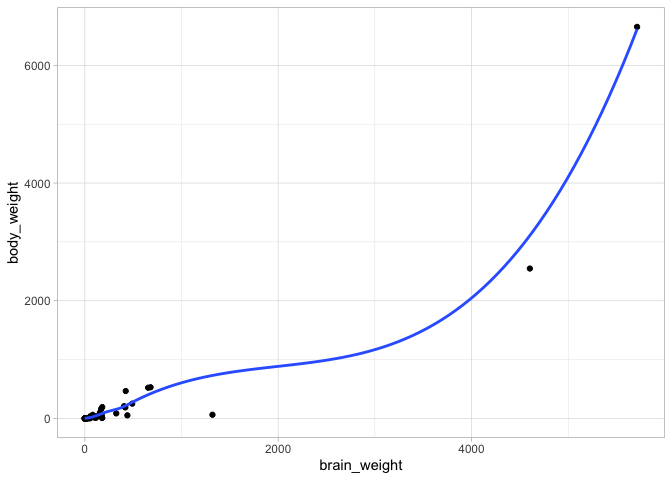

```r
# Examine relationship
ggplot(data = mammal, aes(x = brain_weight, y = body_weight)) +
  geom_point() +
  geom_smooth(se = FALSE) +
  theme_light()
```

The relationship is non-linear, and shows an exponential growth curve. Use the Rule of the Bulge mnemonic, we identify this curve in the lower right-hand quadrant. To help straighten this curve we can either:

- Transform *X* using an upward transformation; or
- Transform *Y* using a downward transformation

Since there is only a single predictor, transforming *Y* is low-cost (it doesn’t affect the relationship between *Y* and other predictors), whereas transforming *X* with an upward transformation means we would have to include more than one effect in the model (e.g., $X$ and $X^2$).

Because of this I will transform *Y* using the log-transformation. Looking at the relationship between ln(body weight) and brain weight, we will see if this “straightened” the relationship.

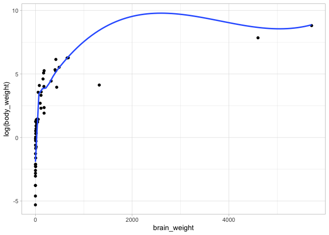

```r
ggplot(data = mammal, aes(x = brain_weight, y = log(body_weight))) +
  geom_point() +
  geom_smooth(se = FALSE) +
  theme_light()
```

The relationship is non-linear, and shows a decay version of the exponential growth curve. Use the Rule of the Bulge mnemonic, we identify this curve in the upper left-hand quadrant. To help straighten this curve we can either:

- Transform *X* using an downward transformation; or
- Transform *Y* using an upward transformation

Since we just used a downward transformation on *Y* to fix the last relationship, using an upward transformation now would just re-introduce the initial problem. Because of this I will transform *X* using the log-transformation. Looking at the relationship between ln(body weight) and ln(brain weight), we will see if this “straightened” the relationship.

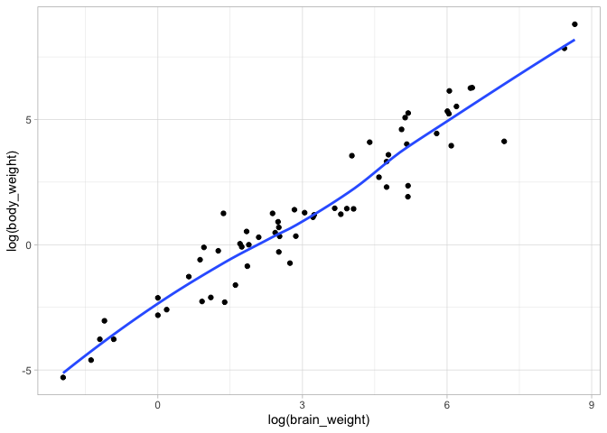

```r
ggplot(data = mammal, aes(x = log(brain_weight), y = log(body_weight))) +
  geom_point() +
  geom_smooth(se = FALSE) +
  theme_light()
```

This relationship looks linear! So we can fit a linear model that uses ln(brain weight) to predict variation in ln(body weight). We can then use back-transformations and a plot of the fitted equation to interpret the coefficients in the model.

## Fit Linear Model

Fitting the linear model and looking at it’s output:

```r
# Fit model
lm.1 = lm(log(body_weight) ~ 1 + log(brain_weight), data = mammal)

# Model-level output
glance(lm.1)
```

```
## # A tibble: 1 x 12
##   r.squared adj.r.squared sigma statistic  p.value    df logLik   AIC   BIC
##       <dbl>         <dbl> <dbl>     <dbl>    <dbl> <dbl>  <dbl> <dbl> <dbl>
## 1     0.921         0.919 0.886      697. 9.84e-35     1  -79.5  165.  171.
## # … with 3 more variables: deviance <dbl>, df.residual <int>, nobs <int>
```

```r
# Coefficient-level output
tidy(lm.1)
```

```
## # A tibble: 2 x 5
##   term              estimate std.error statistic  p.value
##   <chr>                <dbl>     <dbl>     <dbl>    <dbl>
## 1 (Intercept)          -2.51    0.184      -13.6 4.98e-20
## 2 log(brain_weight)     1.22    0.0464      26.4 9.84e-35
```

Interpreting this output:

- Differences in mammals’ brain weight explain 92.1% of the variation in body weight.

The fitted equation is:

$$\hat{\ln(\mathrm{Body~Weight})}_i = -2.51 + 1.22\bigg[\ln(\mathrm{Brain~Weight}_i)\bigg]$$

- Mammals with a log(brain weight) of 0 have a predicted log(body weight) of $-2.51$, on average.
- Each one-unit change in log(brain weight) is associated with a change in log(body weight) of 1.22-units, on average.

We can also back-transform these log entities to get a better interpretation of the coefficients. For the intercept, when log(brain weight) is 0, actual brain weight = 1. Thus, mammals with a 1-gram brain weight have a predicted log(body weight) of $-2.51$, on average. Exponentiating this ($e^{-2.51}=0.081$), so we can interpret the intercept as:

- Mammals with a brain weight of 1 gram have a predicted body weight of 0.081 kg, on average.

To consider the interpretation of the slope, we utilize the fact that log-transforming *X* (using the natural logarithm) results in an interpretation that can be interpreted as a 1% change in *X*. As such, we choose a series of brain weights that differ by 1% and plug them into our fitted equation to get predicted log(body weights):

```r
# Choose brain weights that differ by 1%
body = c(100, 101, 102.01)

# Get predicted ln(body weight) values
-2.51 + 1.22 * log(body)
```

```
## [1] 3.108308 3.120447 3.132586
```

The interpretation is:

- Each 1% difference in brain weight is associated with a difference of 0.012 in log(body weight), on average.

Here 0.012 is the slope coefficient divided by 100. Now let’s transform the log(body weight) values to raw body weights. To do this, we exponentiate these predicted values:

```r
# Exponentiate the predicted values
exp(-2.51 + 1.22 * log(body))
```

```
## [1] 22.38313 22.65651 22.93322
```

This results in a constant multiplicative difference of 1.0122, Namely,

- Each 1% difference in brain weight is associated with a 1.012-fold difference in body weight, on average.

Or, interpreting this as a percent change:

- Each 1% difference in brain weight is associated with a 1.22% difference in body weight, on average.

This 1.22% change is essentially the slope coefficient from the fitted equation. Thus when we log-transfomr both *X* and *Y* using the natural logarithm, we can interpret both the change in *X* and change in *Y* as a percent change. In general:

- Each 1% difference in *X* is associated with a $\hat\beta_1$% difference in *Y*, on average.

We can also plot the fitted curve to facilitate a graphical interpretation.

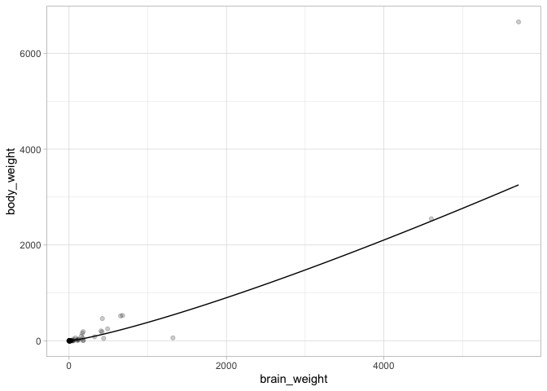

```r
# Plot fitted curve
ggplot(data = mammal, aes(x = brain_weight, y = body_weight)) +
  geom_point(alpha = 0.2) +
  geom_function(fun = function(x){exp(-2.509 + 1.225*log(x))}) +
  theme_light()
```